# NYU SURP 2019 R course

Eugene Plavskin

Grace Avecilla

Summer 2019

# Class 1 (06-18-19): Introduction

## Downloading, installing, and navigating Rstudio

In this series of workshops, we will be using the R programming language. In order to be able to complete the exercises in the workshops, you will need to download R onto your computer. You will also need to download RStudio, a programming environment that will make it easier to visualize what we are doing.

R is available for **free** at r-project.org. There’s versions for Windows, Mac, *nix. Download and install it. You can open it to see if it worked. You enter commands by typing them and pressing enter. R should spit back a response of some kind. One thing you can do is type `version` and hit enter. It’ll respond with the version. You should have downloaded the latest version, around 3.5.1 or later.

R itself is pretty minimal, so we’ll want to download [RStudio](https://www.rstudio.com/products/rstudio/download/) as well. RStudio is a graphical user interface (GUI) integrated development environment (IDE) for using R. RStudio will make it easier for us to write and edit our code, view plots, and make documents like this one. RStudio Desktop is also free.

## Getting organized

Make yourself a folder for this work, I’ll assume it’s called “introR” but you can call it whatever you like. AVOID using spaces, use _ (my_directory) or CapitalizeEachWord (ThisIsCalledCamelCase). Why no spaces? They’re harder to type for when navigating directories from within R. Give directories informative names, it’ll help you later on. Use consistent naming schemes, choose either CamelCase or underscores.

## Packages

One of the best things about R is that there is a huge community of scientists and programming constantly developing new things and making them available (for free!) for everyone else to use. One of the most common ways these new functionalities are shared is in *packages*. These are essentially collections of various related functionalities–for example, for reshuffling data, doing some special statistical analysis, or plotting. For now, we will use two special R packages besides what automatically comes with the programming language: **knitr**, which is what makes R notebooks into the pretty HTML documents you’re reading now, and **ggplot2**, which allows you to beautifully and easily plot your data.

```r
#install.packages('knitr')
#install.packages('ggplot2')
```

You don’t have to re-install packages every time you open R. However, you *do* have to tell R that you’re planning to use some function from a particular package and want R to look there when you’re asking it to do things:

```r
library(ggplot2)
library(knitr)
```

## What will we learn?

This class will give you an introduction into how to code in the context of asking questions about data. We’re going to learn how to read in data; how to use R to perform computations on this data that would be difficult (or impossible, depending on how much data you’re working with) to perform otherwise, such as simultaneously computing averages of various categories of data points that you select; and how to plot your data and the results of the analyses you perform.

We hope that by the end of the class, you will feel relatively comfortable using R to perform some analysis on data that you have collected (or even data someone else has collected!) and to plot the results. These are practical skills that you will find useful in a wide range of fields, not just biology.

This class is *not* a comprehensive introduction to coding. There will be lots more to learn after you are done with the SURP program if you’re interested in pursuing computational work more seriously. But in our experience, learning the first bits of coding can present a huge barrier to students (it certainly did for us and many of our colleagues). We hope that we’ll be able to break this barrier down for you over the course of the summer.

Here is an example of some work that was done by a SURP student last summer, Janessa Vail

```r
# First, we load in the data
# get Rstudio to figure out the directory in which this file is
current_path <- dirname(rstudioapi::getSourceEditorContext()$path)
# Look for Janessa's data in that directory
load(file.path(current_path, 'Janessa_GR_data.Rdata'))
# Show Janessa's data table
View(Janessa_growth_rate_data)
```

We can immediately see why Janessa’s data would be hard to try to analyze by hand or, let’s say, in excel.

1. There’s LOTS of data. If you look in the ‘Environment’ box on the right side of your screen, you will see that it says something like ‘Janessa_growth…|54491 obs of 16 variables’. This is telling you that the data contains ~55,000 observations (in this case, measurements of growth rate and other things for individual yeast colonies)
2. The data can be subdivided into many categories that might be of interest to our analysis, and the data are not sorted by those categories. For example, let’s take a look at the different strains whose growth rates Janessa measured in this data:

```r
Janessa_strain_list <- unique(Janessa_growth_rate_data$Strain)
print(paste("The unique strains from Janessa's experiment are:",
            paste(Janessa_strain_list, collapse = ', ')))
```

```
[1] "The unique strains from Janessa's experiment are: MAT0.a1, MAH.3"
```

In your data, you may have measurements made in different strains, across different conditions, etc. If you want to easily calculate the means of different combinations of these categories, it can prove difficult in excel, especially with lots of data. We can make tables that summarize the mean and sample size for each strain in Janessa’s experiment:

```r
Janessa_means <- aggregate(data = Janessa_growth_rate_data,
                                  GR ~ Strain,
                                  FUN = mean)
Janessa_sample_sizes <- aggregate(data = Janessa_growth_rate_data,
                                  GR ~ Strain,
                                  FUN = length)
```

```
[1] "Table of growth rate means"
```

| Strain | GR |
| --- | --- |
| MAH.3 | 0.2024575 |
| MAT0.a1 | 0.1768744 |

```
[1] "Table of growth rate sample sizes"
```

| Strain | GR |
| --- | --- |
| MAH.3 | 35752 |
| MAT0.a1 | 18739 |

We also probably want to be able to plot the data, automatically splitting it into whatever categories you’re interested in. Once you know a little bit about how to use it, R makes this very easy! Since Janessa was interested in comparing growth rates between strains, she plotted these:

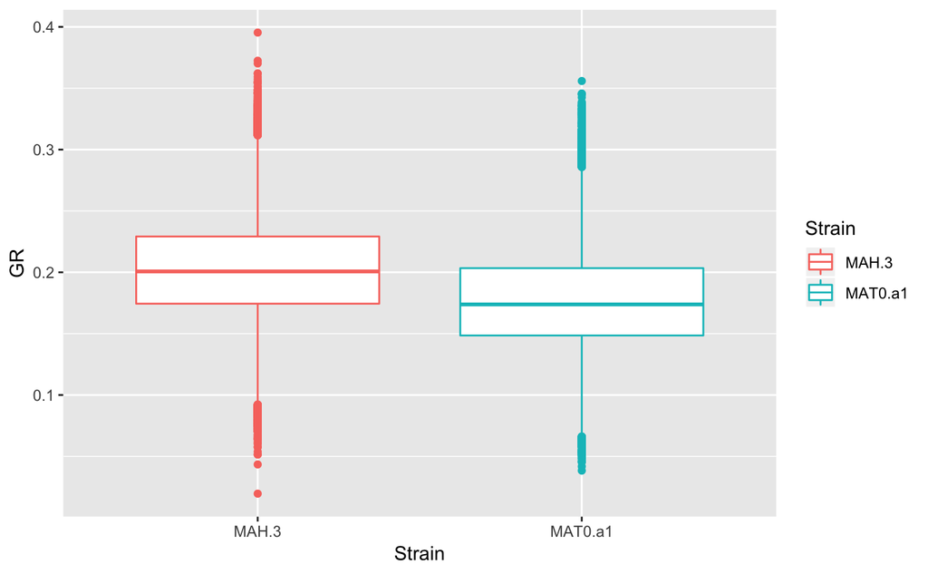

```r
ggplot(data = Janessa_growth_rate_data) +
  geom_boxplot(aes(x = Strain, y = GR, color = Strain))
```

## Using R notebooks

R notebooks are a great way to keep track of a project. They provide a space where code, its output (e.g. plots) and clearly formatted explanations can be kept in one place. Think of it as a lab notebook for your code.

Just like lab notebooks, R notebooks make it much easier to reproduce your own–or another scientist’s–analysis. They can be viewed as formatted both html files (what you are seeing right now) and as an editable pieces of code that can be opened in RStudio. If you email a collaborator an html file of a notebook containing your analysis (together with the underlying data), they can open it up, re-run any part they are interested in, and easily tweak any anylysis you did to check something you may not have thought of.

In this class, every lesson will come with a pre-prepared R notebook. It is critical that you download each lesson’s R notebook at the beginning of class and write your code inside the notebook as we go along. Most of programming is recycling and repurposing code (either code you wrote, or code someone else wrote), and these notebooks will make sure that during the class, you always have access to your old code for repurposing.

To download this lecture’s R notebook, scroll to the top of this website, click ‘Code’, and select ‘Download Rmd’.

Starting a new notebook!

Elements of a notebook:

The notebook contains 3 major parts:

- **YAML**: title, author, date; also, any special options about how you’d like Rstudio to display things in the html document (e.g.: do you want the code to show up?)
- **Markdown Text**: Your descriptions of what you’re doing! This is pretty straightforward. Just type here, and skip lines between paragraphs. You can use asterisks to do special formatting: put a single asterisk on each side of a piece of text for *italic*, two asterisks on each side for **bold**. Other things, like bulletpoints, hyperlinks, etc are also possible.
- **Code Chunks**: These are the parts of your notebook where you include the actual code you want to run! By marking these, you are telling R to read the code and execute it. By default, this code will also show up in your html document, but in specially formatted section so it can be easily seen as being separate from the main text. Mark code chunks by starting with three backticks ( **`**, on the top left of your keyboard, under the **~** ). Then type **{r}**, and start coding on the next line. At the end of your code chunk, on a new line, add 3 more backticks to let R know that the code chunk is over. In Rstudio, these code chunks should show up with gray background shading.

You can highlight specific line (or lines of code) and just run those; you can run an entire code chunk at a time; or you run all the code in the current notebook.

Once you’ve run your code, save your notebook in Rstudio. This will automatically update the formatted html file.

## Trying some coding: R-ithmetic

It’s time to try some coding! Take a look at the code chunk below: if you run the first line, you’ll see that we can use R as a fancy calculator. Let’s practice that: run the line in the code chunk below

```r
5 + 3
```

```
[1] 8
```

Easy! Try some more math in the code chunk below:

```r
# Often, you may want to write a note for yourseld (and anyone else who may read
# your code!) about what each piece of code is doing
# But R interprets anything inside a code chunk as something it has to execute!
# Putting a pound sign in front of a line of code tells R to ignore anything you
# type there, which allows you to make notes for yourself
# These lines are called comments. Comments are *REALLY* important to make code
# readable, write tons of them!
# Below, write a line of code that will add 1 and 5, and run it
# Write a line of code that will subtract 4 from 7, and run it
```

Now let’s level up

## What are students working on? What do they want to learn?

*Fill in during class*

# Class 2 (06-20-19): Basics of programming: variables and functions

## The power of google

Last class, you saw that R can be used as a fancy calculator.

```r
3+4
```

```
[1] 7
```

Let’s use R to do some more math.

In most programming languages, division is written using the slash ( **/** ), and multiplication using the asterisk ( * )

```r
# Try multiplying 8 by 7
# Try dividing 4589 by 124
```

One of the *most* important skills in programming is knowing how to find information. No amount of experience will teach you how to do *everything*, and it’s incredibly easy to forget how to do things that you’ve done many times before but haven’t had to use in a while. Fortunately, we have google!

Try searching online to find out how to do the exercises in the code chunk below:

```r
# Take 3 to the 5th power
# Find the remainder when 8 is divided by 3
```

You may have seen some answers on a website called *StackOverflow*. This is a great site that allows people to ask questions and they are answered by members of the R community. In most cases, there was already someone who had your question at some point, which is why a clever google search can usually help you figure out how to do most things. There are also a ton of blogs online that teach you specific skills in R.

## Variables

### Variables hold information

Defining variables, or giving a name to values, such as the numbers you added together, allows you to store information.  
You define variables using the `<-` operator, which means “store the value on the right in the variable on the left”, like so. You can then call it back by saying the variable name.

```r
variable1 <- 3
variable2 <- 4
variable1
```

```
[1] 3
```

You can use variables in the place of the numbers they hold, and perform mathematical operations on them.

```r
variable1 + variable2
```

```
[1] 7
```

As their name implies, variables can take on many values, and can change, so be careful with naming and assignment.

```r
variable1 <- variable1 + variable2
variable1
```

```
[1] 7
```

```r
variable1 <- variable1 + variable2
variable1
```

```
[1] 11
```

### Variable *types*

These types of variables are *numeric*. However, R can also store text. These are in the form of *characters*. Surround characters in quotation marks to have them be character and not variable names.

```r
char <- "a"
char
```

```
[1] "a"
```

```r
# In your console, try typing 'char <- a' (no quotes) and seeing what happens
```

Characters variables can store *strings*, such as words and sentences (in fact, in R, *string* and *character* are basically interchangeable). In R, one string (everything between the quotation marks) is stored as a single unit.

```r
char_sentence <- "My favorite food is ice cream"
char_sentence
```

```
[1] "My favorite food is ice cream"
```

```r
char_variable1 <- "variable1"
char_variable1
```

```
[1] "variable1"
```

```r
char_variable2 <- variable1
char_variable2
```

```
[1] 11
```

You can identify the type of variable (numeric, character) using `is()`.

```r
# Using is()
is(5)
```

```
[1] "numeric" "vector"
```

```r
# Try identifying the type of variable for char_variable1
# How about char_variable2?
# What is going on?
```

You can also make numbers into strings: just put a quote around them!

```r
num_string <- '4'
actual_num <- 4
# Try identifying the types of num_string and actual_num
```

You need to be very careful about the types of your variables. It may look like *actual_num* and *num_string* are holding the same thing, but because we’ve implicitly told R that they are of different types, they behave very differently. In the **Console**, try adding *num_string* to *actual_num*. What happens, and why? What is R’s cryptic message trying to tell you?

## Functions

### Adding with functions

We saw above that you can do basic arithmetic in R by just using mathematical symbols, e.g. **+**. But for more complicated things, programming languages use things called *functions*. A function is something that wraps a whole set of operations so that you can invoke those operations in a single command. You have already used another function earlier in this class, `is()`. Let’s take a look at another example: there’s a function, `sum()`, that can add numbers, just like **+** can. Let’s try it:

```r
variable1
```

```
[1] 11
```

```r
variable2
```

```
[1] 4
```

```r
sum(variable1, variable2)
```

```
[1] 15
```

Functions are their own type! You can try using `is()` to check this:

```r
is(sum)
```

```
[1] "function"         "OptionalFunction" "PossibleMethod"
```

```r
is(is)
```

```
[1] "function"         "OptionalFunction" "PossibleMethod"
```

Functions are always followed by `()` when you use them. When you use a function, often you are telling it to perform an operation on something else (e.g. a variable); in the examples above, we’re performing the `sum()` function on *variable1* and *variable2*, and we’re performing the `is()` function on `sum` and on itself. These are called arguments, and are *passed* to the function inside the parentheses.

### Looking at the **Environment**

Some functions don’t need to take any arguments. For example, you can find out what variables you have loaded in your *environment* at anytime using `ls()`. This will list all your variables, any custom functions you may have written, etc.

```r
ls()
```

```
 [1] "actual_num"               "char"                     "char_sentence"
 [4] "char_variable1"           "char_variable2"           "current_path"
 [7] "Janessa_growth_rate_data" "Janessa_means"            "Janessa_sample_sizes"
[10] "Janessa_strain_list"      "num_string"               "variable1"
[13] "variable2"
```

Check out the **Environment** window on the top right! You can actually also see all your variables loaded in there, with a short summary of what’s in them. This is a super convenient feature of programming in Rstudio.

### Combining strings

Another really useful function is the `paste` function; this function allows you to combine *strings*.

```r
research_program <- 'SURP'
year <- '2019'
current_program <- paste(research_program, year)
```

Notice that the code above didn’t print anything out. That’s because we directed the output of the `paste` function into a variable, *current_program*. To get R to print out the current program variable, you could just type it into your console, or you could use a function! Try googling to find an R function that prints out a variable.

```r
# Find an R function to print out a variable, and use it to print whatever
# the current_program variable is storing
```

You can learn about a function by reading its documentation. You can access the documentation with `?`, for example, type `?paste` into your console. You will see the help text pop up in the bottom right Help box in Rstudio.

`?` is one of the more important keys for you to know. Seriously, many issues are averted by first checking the documentation. Documentation usually has:

- A description of the intention of the function
- How to use it, ie where to put what arguments
- A description of what those arguments should be
- Details, and what value they return
- And if you’re lucky, examples of usage

In practice, this information can sometimes be a bit dense and technical. I usually find it most useful to read the ‘description’ on top, and then scroll all the way down to the ‘examples’ section at the bottom of the help function.

Notice that when we used paste above, the function automatically put a space between our two strings. It’s often really useful to combine strings with a different character, for example, a dash. Try to read the documentation for `paste()` to figure out how to do this.

```r
# Combine the research_program and year variables using just a hyphen between
# them instead of a space
```

## Things we hope you’ve learned today (and will hopefully remember next time)

- *variables* hold information
- Basic types: *numeric*, *character*, and *function*
- How to use functions, and what *arguments* are
- How to use `sum()`, `paste()`, `is()`
- How to look at your **Environment**

# Class 3 (06-27-19): Vectors: doing stuff to numbers and characters

```r
# Based on the documentation from of seq, make the sequence: 1, 2, 3, 4
# Now make the sequence: 2, 2.5, 3, 3.5
# Identify what values are corresponding to what arguments
```

## Introduction to vectors

Show number vectors and character vectors

```r
include_graphics('vector_illustration1.png')
```

[output not shown]

## Operations on vectors of numbers

- Adding a single number to vector
- Adding two vectors of same size
- Warning: adding two vectors of different sizes

## Operations on vectors of characters

Paste function

## length()

## Indexing

Using position names instead of numerical position indices

```r
include_graphics('vector_illustration_names.png')
```

[output not shown]

## Converting between numeric and character types

# Class 4 (07-02-19): Missing values and logical operations

## When we get missing values

- Try dividing two vectors by each other that both have a 0
- Unmeasured data in experiment, etc

## Logicals

- is.na()
- vectors of logicals
- 1s and 0s as logicals, sum()
- selecting and replacing values from vectors based on logicals
- operations on logicals (AND, OR)
- which()
- mean() with na.rm = T

## if() / else() ???

# Class 5 (07-09-19): Data Frames: Reading in and manipulating data, writing data

```r
include_graphics('df_illustration.png')
```

[output not shown]

## Reading in tables from excel

Teach them about csv format

## Selecting data from data frames: row numbers and column numbers and $

## Creating new columns from operations on other columns

## Creating new data frames from scratch and writing them

## Watch out for factors!

# Class 6 (07-11-19): basic stats on data frames + base plot

## Calculate column means, standard deviations, standard errors

## scatter-plot some columns against each other

## Discuss more of what we’d like to do (hints at subsetting, ggplot)

# Class 7 (07-16-19): Practice with data frames: read in and process example data

- Need some good examples for them to work with–at least incl. single-cell data

# Class 8 (07-18-19): Practice with data frames: present example data

# Class 9 (07-23-19): Subsetting data

## Subset data frames using indices

## Subset data frames using logical operations

## subset()

# Class 10 (07-25-19): Aggregating data and generating summary tables

## table() for counting elements

## examples with aggregate()

## summarise() from dplyr???

## summary() ???

# Class 11 (07-30-19): Introduction to ggplot: point plots

## Install package, load library

## Scatterplot some e.g. iris data

- Show scatterplot as we did it earlier in the class, but with ggplot
- Color by species
- shape by species

## Point plot aggregate data (e.g. means across categories)

# Class 12 (08-01-19): Doing basic stats on data

## t-tests

## standard error (in the context of aggregate() )

## linear regression

# Class 13 (**currently off the schedule, need to integrate into prev classes**): Fancier ggplots

## summary plot with error bars

## scatterplot with regression line

## Box plots

## Bar plots

## Line graphs

## Density plots?

## HOW do you present what kind of data?!

# OPTIONAL: LOOPS AND FUNCTIONS